# Sixth Week: Linear Models

House price prediction

Kimia Hamidieh (95109434)

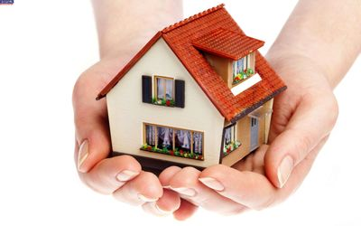

> با توجه به داده های قیمت منازل لطفا با سوالات زیر پاسخ دهید.

۱. ماتریس همبستگی متغیرهای مختلف را به دست آورده و سپس رسم نمایید. اعداد به دست آمده را با آزمون فرض معناداری همبستگی بسنجید و سپس ده متغیری که همبستگی بالاتری با قیمت دارند را مشخص نمایید.

با توجه به این که corrolation برای متغیرهای عددی استفاده می شود، پارامترهای غیرعددی را از داده حذف می کنیم. که البته می توان با استفاده از factor به دسته ای از آن ها (که می توان آن ها را به صورت عدد طبقه بندی کرد) عدد نسبت داد که البته در این صورت انگار اولویتی برای گزینه های مختلف قائل شده ایم و بنابرای بهتر است همه ی متغیرهای غیرعددی را حذف کرد.

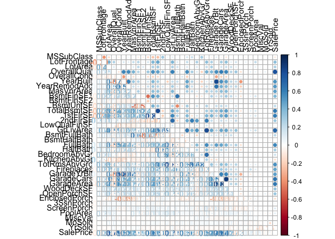

```r
houses = read_csv("house_data/train.csv")

library("Hmisc")

houses %>%
  subset(select = -Id) %>%
  select_if(is.numeric) %>%
  as.matrix() %>%
  rcorr() -> cor_numerics

cor_mat = cor_numerics$r
cor_pvals = cor_numerics$P

library(corrplot)
# corrplot(cor_mat, p.mat = cor_pvals, method = "square", insig = "blank")
corrplot.mixed(cor_mat, tl.col="black", tl.pos = "lt")
```

```r
as.data.frame(cor_mat) %>%
  cbind(vars = row.names(cor_pvals), .) %>%
  arrange(-SalePrice) %>%
  slice(2:11) %>% # sale price has cor = 1 with itself
  select(vars, cor = SalePrice) -> related_vars
related_vars
```

```
## # A tibble: 10 x 2
##    vars           cor
##    <fct>        <dbl>
##  1 OverallQual  0.791
##  2 GrLivArea    0.709
##  3 GarageCars   0.640
##  4 GarageArea   0.623
##  5 TotalBsmtSF  0.614
##  6 1stFlrSF     0.606
##  7 FullBath     0.561
##  8 TotRmsAbvGrd 0.534
##  9 YearBuilt    0.523
## 10 YearRemodAdd 0.507
```

۲. در یک تصویر نمودار پراکنش دو به دو ده متغیر بدست آمده به همراه قیمت را رسم نمایید و هم خطی بودن متغیرها را بررسی کنید

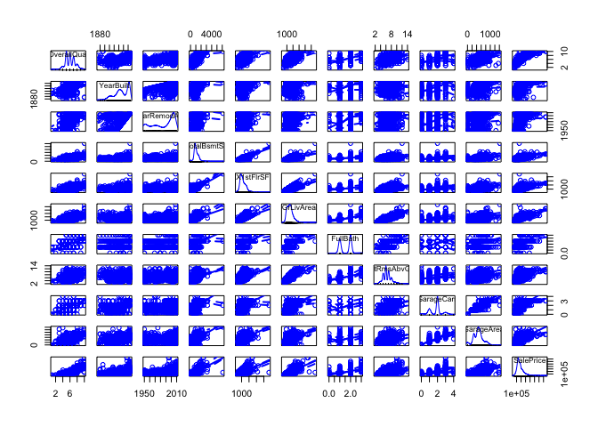

```r
library("car")
houses_clean = cbind(houses[which(colnames(houses) %in% related_vars$vars)], SalePrice = houses$SalePrice)
# plot(houses_clean)
scatterplotMatrix(x = houses_clean, formula = SalePrice ~ .)
```

در نمودارهای کشیده شده، برای بررسی این که آیا دو متغیر هم خط اند یا خیر می توان چک کرد که آیا در نمودارهای کشیده شده، نقاط را می توان با خطی تخمین زد یا خیر. در این جا با توجه به اینکه مقدار عرض از مبداها احتمالاً کم است، به تعداد نقاط نزدیک به نمیساز ربع اول و سوم توجه شده است که با توجه به نمودارها، اکثر متغیرها با قیمت خانه هم خط اند.

۳. یک مدل خطی بر اساس ده متغیر برای پیش بینی قیمت برازش دهید. و سپس خلاصه نتایج مدل را به دست آورید.

```r
linear_model = lm(formula = SalePrice ~ ., data = houses_clean)
summary(linear_model)
```

```
##
## Call:
## lm(formula = SalePrice ~ ., data = houses_clean)
##
## Residuals:
##     Min      1Q  Median      3Q     Max
## -489958  -19316   -1948   16020  290558
##
## Coefficients:
##                Estimate Std. Error t value Pr(>|t|)
## (Intercept)  -1.186e+06  1.291e+05  -9.187  < 2e-16 ***
## OverallQual   1.960e+04  1.190e+03  16.472  < 2e-16 ***
## YearBuilt     2.682e+02  5.035e+01   5.328 1.15e-07 ***
## YearRemodAdd  2.965e+02  6.363e+01   4.659 3.47e-06 ***
## TotalBsmtSF   1.986e+01  4.295e+00   4.625 4.09e-06 ***
## `1stFlrSF`    1.417e+01  4.930e+00   2.875 0.004097 **
## GrLivArea     5.130e+01  4.233e+00  12.119  < 2e-16 ***
## FullBath     -6.791e+03  2.682e+03  -2.532 0.011457 *
## TotRmsAbvGrd  3.310e+01  1.119e+03   0.030 0.976404
## GarageCars    1.042e+04  3.044e+03   3.422 0.000639 ***
## GarageArea    1.495e+01  1.031e+01   1.450 0.147384
## ---
## Signif. codes:  0 '***' 0.001 '**' 0.01 '*' 0.05 '.' 0.1 ' ' 1
##
## Residual standard error: 37920 on 1449 degrees of freedom
## Multiple R-squared:  0.7737, Adjusted R-squared:  0.7721
## F-statistic: 495.4 on 10 and 1449 DF,  p-value: < 2.2e-16
```

۴. نمودار قیمت واقعی و قیمت پیش بینی را رسم نمایید و خوب بودن مدل را ارزیابی کنید.

```r
houses_plot = cbind(houses_clean, Estimated = fitted(linear_model) %>% as.vector())
head(houses_plot)
```

```
##   OverallQual YearBuilt YearRemodAdd TotalBsmtSF 1stFlrSF GrLivArea
## 1           7      2003         2003         856      856      1710
## 2           6      1976         1976        1262     1262      1262
## 3           7      2001         2002         920      920      1786
## 4           7      1915         1970         756      961      1717
## 5           8      2000         2000        1145     1145      2198
## 6           5      1993         1995         796      796      1362
##   FullBath TotRmsAbvGrd GarageCars GarageArea SalePrice Estimated
## 1        2            8          2        548    208500  214741.7
## 2        2            6          2        460    181500  169346.7
## 3        2            6          2        608    223500  220816.5
## 4        1            7          3        642    140000  199794.2
## 5        2            9          3        836    250000  282278.3
## 6        1            5          2        480    143000  156259.7
```

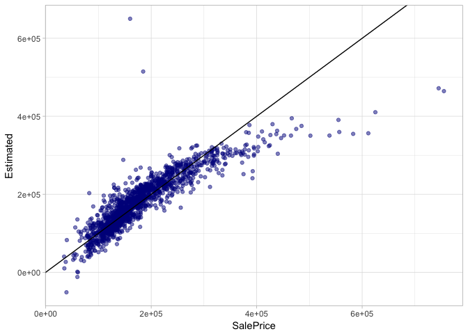

```r
ggplot(data = houses_plot, aes(x = SalePrice, y = Estimated)) +
  geom_point(alpha = 0.5, color = "dark blue") + geom_abline(slope = 1) + theme_light()
```

همان طور که در نمودار $Y$ به $\hat{Y}$ مشاهده می شود، اکثر نقاط بسیار نزدیک به خط $y = x$ است. بنابراین در اکثر نقاط مقدار تخمین زده شده بسیار نزدیک به مقدار واقعی بوده و مدل نسبتاً خوب است. (به جز در داده ها با قیمت بالا که تعداد آن ها نیز نسبتاً کم است.)

۵. مقدار R-squared مدل را به دست آورید. آیا بر اساس این کمیت مدل به خوبی به داده ها برازش داده شده است؟ کمیت F-statistic را در خلاصه مدل تفسیر نمایید.

```r
summary(linear_model)$r.squared
```

```
## [1] 0.7736928
```

کمیت r-squared معیاری است که به ما نشان می دهد که داده ها چقدر به خط تخمین زده نزدیکند. و در واقع درصد (در این جا در رنج ۰ تا ۱) داده هایی که به تخمین مورد نظر نزدیکند و با آن قابل توضیحند را نشان می دهد. (کاری که این کمیت انجام می دهد با توجه به فرمول زیر این است که خطای ناشی از واریانس $Y$ که در دیگر کمیت ها وجود دارد از بین رفته است.)

$$R^2 = 1 - \dfrac{SS_{res}}{SS_{tot}}, SS_{res} = \sum(Y_i - \hat{Y_i})^2, SS_{tot} = \sum (Y_i - \bar{Y_i})^2$$

با توجه به مقدار r-squared این مدل می توان به این نتیجه رسید که مدل داده شده، نسبتاً خوب است اما باید توجه داشت که مقدار کم یا زیاد r-squared لزوماً به معنای این که مدل حتماً خوب و یا حتماً بد است نیست. اما در کل مقدار r-squared بالای ۰.۶ برای یک مدل خوب حتماً لازم است که در این جا این شرط برقرار است.

```r
summary(linear_model)$fstatistic
```

```
##     value     numdf     dendf
##  495.3802   10.0000 1449.0000
```

کمیت F-statistic در این جا، معیاری است که در حالت کلی معنی دار بودن مدل رگرسیونی را تعیین می کند (این که آیا حداقل یکی از متغیرهای در نظر گرفته شده در مدل معنی دار هست یا نه). در واقع یک F-test روی داده ها اجرا می شود به طوری که فرض صفر این است که تمام ضرایب مدل رگرسیونی صفرند. (یک F-test معادل چندین بار استفاده از t-test برای متغیرهای مختلف است.) و یا معادلاً مدل درنظر گرفته شده کارایی بالایی ندارد. نهایتاً مقدار F-statistic که در مدل خطی ما (با استفاده از lm) حساب شده است، نشانه ی این است که آیا متغیرهای در نظر گرفته شده با قیمت خانه ارتباطی دارد یا نه (مدل بهتر از حالت رندوم هست یا خیر). حال اگر مقدار آن بسیار بیشتر از ۱ باشد، (که در این جا با توجه به نسبت آن به تعداد داده ها خیلی خیلی بیشتر است) با توجه به مقدار p-value در آخرین سطر summary، فرض صفر رد شده و مدل در نظر گرفته شده معنی دار است.

۶. بر اساس p-value سطح معناداری ضرایب تصمیم بگیرید که چه متغیرهایی در مدل سازی استفاده شود. بر اساس متغیرهای جدید دوباره مدل سازی کنید و نتایج رو گزارش دهید.

```r
vars = related_vars$vars
vars = vars[vars != "TotRmsAbvGrd"]
houses_clean = cbind(houses[which(colnames(houses) %in% vars)], SalePrice = houses$SalePrice)
linear_model = lm(formula = SalePrice ~ ., data = houses_clean)
summary(linear_model)
```

```
##
## Call:
## lm(formula = SalePrice ~ ., data = houses_clean)
##
## Residuals:
##     Min      1Q  Median      3Q     Max
## -490056  -19317   -1948   16028  290442
##
## Coefficients:
##                Estimate Std. Error t value Pr(>|t|)
## (Intercept)  -1.186e+06  1.283e+05  -9.241  < 2e-16 ***
## OverallQual   1.960e+04  1.188e+03  16.505  < 2e-16 ***
## YearBuilt     2.681e+02  5.016e+01   5.345 1.05e-07 ***
## YearRemodAdd  2.964e+02  6.360e+01   4.661 3.43e-06 ***
## TotalBsmtSF   1.986e+01  4.283e+00   4.636 3.87e-06 ***
## `1stFlrSF`    1.417e+01  4.928e+00   2.876 0.004083 **
## GrLivArea     5.138e+01  3.107e+00  16.536  < 2e-16 ***
## FullBath     -6.780e+03  2.658e+03  -2.551 0.010832 *
## GarageCars    1.043e+04  3.033e+03   3.438 0.000603 ***
## GarageArea    1.493e+01  1.028e+01   1.452 0.146838
## ---
## Signif. codes:  0 '***' 0.001 '**' 0.01 '*' 0.05 '.' 0.1 ' ' 1
##
## Residual standard error: 37910 on 1450 degrees of freedom
## Multiple R-squared:  0.7737, Adjusted R-squared:  0.7723
## F-statistic: 550.8 on 9 and 1450 DF,  p-value: < 2.2e-16
```

```r
vars = vars[vars != "GarageArea"]
houses_clean = cbind(houses[which(colnames(houses) %in% vars)], SalePrice = houses$SalePrice)
linear_model = lm(formula = SalePrice ~ ., data = houses_clean)
summary(linear_model)
```

```
##
## Call:
## lm(formula = SalePrice ~ ., data = houses_clean)
##
## Residuals:
##     Min      1Q  Median      3Q     Max
## -482525  -19191   -1801   16208  289639
##
## Coefficients:
##                Estimate Std. Error t value Pr(>|t|)
## (Intercept)  -1.188e+06  1.284e+05  -9.255  < 2e-16 ***
## OverallQual   1.959e+04  1.188e+03  16.486  < 2e-16 ***
## YearBuilt     2.699e+02  5.017e+01   5.380 8.69e-08 ***
## YearRemodAdd  2.957e+02  6.362e+01   4.649 3.64e-06 ***
## TotalBsmtSF   2.039e+01  4.269e+00   4.775 1.98e-06 ***
## `1stFlrSF`    1.465e+01  4.919e+00   2.979  0.00294 **
## GrLivArea     5.177e+01  3.097e+00  16.714  < 2e-16 ***
## FullBath     -7.184e+03  2.644e+03  -2.717  0.00666 **
## GarageCars    1.395e+04  1.817e+03   7.680 2.92e-14 ***
## ---
## Signif. codes:  0 '***' 0.001 '**' 0.01 '*' 0.05 '.' 0.1 ' ' 1
##
## Residual standard error: 37920 on 1451 degrees of freedom
## Multiple R-squared:  0.7734, Adjusted R-squared:  0.7721
## F-statistic: 618.9 on 8 and 1451 DF,  p-value: < 2.2e-16
```

با توجه به مقدارهای p-value برای هر متغیر، در هر مرحله متغیر با بیشترین p-value را حذف می کنیم تا جایی که تمام متغیرها p-value کمتر از ۰.۰۱ داشته باشند.

۷. مدل خود را بر اساس باقی مانده نقص یابی کنید. سه محک normality, independance, Constant Variance را در نقص یابی خود در نظر بگیرید.

### Constant Variance

در این جا با استفاده از پلات زیر، فرض ثابت بودن واریانس را بررسی می کنیم. در این جا خط بنفش نشان دهنده ی مدل خطی است که دلیل دو تکه بودن آن این است که در $Y$ های بسیار کم، مدل خطی عمل نکرده است. هرچند که تا مقدار حدود e+05 این مشکل پابرجاست. اما از لحاظ constant variance مدل نسبتا خوب است. چرا که خط چین کشیده شده نسبت به خط رگرسیون نسبتاً صاف بوده و همچنین همان طور که از شکل مشخص است نقاط در xهای مختلف تقریبا یکسان پخش شده اند. (به جز در حدود2e+05)

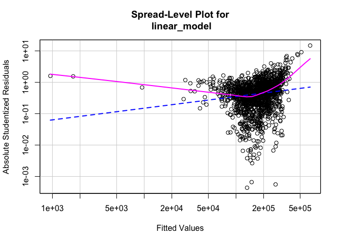

```
##
## Suggested power transformation:  0.6280349
```

```r
spreadLevelPlot(linear_model)
```

### Normality

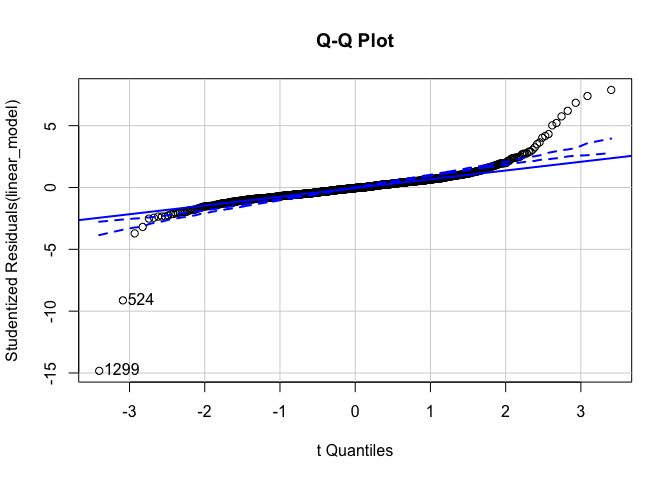

```
## [1]  524 1299
```

```r
library("car")
qqPlot(linear_model, id.method = "identify", simulate = TRUE, main="Q-Q Plot")
```

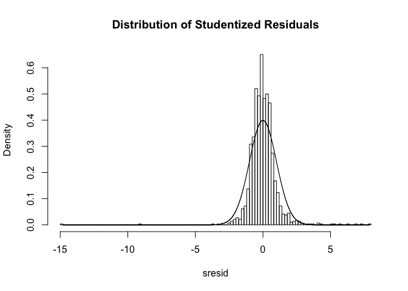

```r
library("MASS")
sresid = studres(linear_model)
hist(sresid, freq=FALSE, main = "Distribution of Studentized Residuals", breaks = 100)
xfit = seq(min(sresid),max(sresid),length=10000)
yfit = dnorm(xfit)
lines(xfit, yfit)
```

### Independance

برای تشخیص مستقل بودن errorها می توان از نمودار residul بر اساس زمان اتفاق (یا مثلاً در این جا شماره سطر) استفاده کرد. به طوری که اگر در زمان های مختلف داده ها یکسان پخش شده بودند، مستقلند.

که در این جا این شرط با توجه به نمودار برقرار بوده و شرط independence نیز برقرار است.

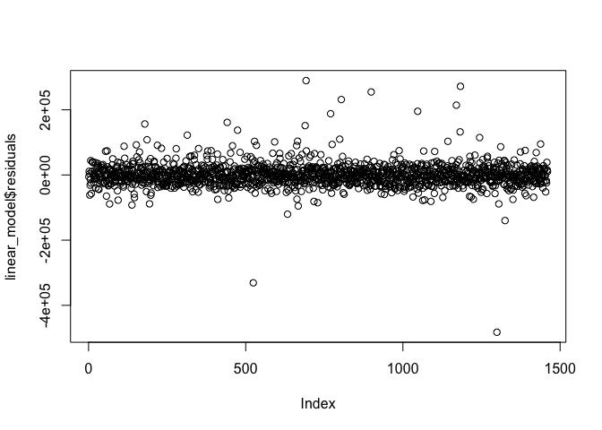

```r
plot(linear_model$residuals)
```

۸. داده ها را به پنج قسمت تقسیم کنید. بر اساس چهار قسمت مدل خطی را بسازید و صحت مدل را برای یک قسمت باقی مانده را تست کنید. خطای پیش بینی شما چقدر است؟

```r
n = nrow(houses)
train = houses %>% as.data.frame() %>% slice(1:(4*n/5 - 1))
test = houses%>% as.data.frame() %>% slice((4*n/5):n)

train %>%
  select_if(is.numeric) %>%
  cor(use = "complete.obs") -> cor_mat_numerics

train %>%
  # subset(select = -Id) %>%
  select_if(is.numeric) %>%
  as.matrix() %>%
  rcorr() -> cor_numerics

cor_mat = cor_numerics$r
cor_pvals = cor_numerics$P

as.data.frame(cor_mat) %>%
  cbind(vars = row.names(cor_pvals), .) %>%
  arrange(-SalePrice) %>%
  slice(2:11) %>%
  dplyr::select(vars, SalePrice) -> related_vars

train_clean = cbind(train[which(colnames(train) %in% related_vars$vars)], SalePrice = train$SalePrice)
test_clean = cbind(test[which(colnames(test) %in% related_vars$vars)], SalePrice = test$SalePrice)

train_model = lm(formula = SalePrice ~ ., data = train_clean)
summary(train_model)
```

```
##
## Call:
## lm(formula = SalePrice ~ ., data = train_clean)
##
## Residuals:
##     Min      1Q  Median      3Q     Max
## -356856  -18150   -1872   14956  274321
##
## Coefficients:
##                Estimate Std. Error t value Pr(>|t|)
## (Intercept)  -1.381e+06  1.339e+05 -10.309  < 2e-16 ***
## OverallQual   1.696e+04  1.250e+03  13.576  < 2e-16 ***
## YearBuilt     2.980e+02  5.170e+01   5.764 1.05e-08 ***
## YearRemodAdd  3.657e+02  6.556e+01   5.578 3.03e-08 ***
## TotalBsmtSF   3.251e+01  4.503e+00   7.221 9.36e-13 ***
## `1stFlrSF`    8.497e+00  5.067e+00   1.677   0.0938 .
## GrLivArea     5.685e+01  4.549e+00  12.499  < 2e-16 ***
## FullBath     -9.085e+03  2.777e+03  -3.272   0.0011 **
## TotRmsAbvGrd  1.113e+03  1.182e+03   0.942   0.3465
## GarageCars    7.971e+02  3.204e+03   0.249   0.8036
## GarageArea    4.343e+01  1.068e+01   4.068 5.07e-05 ***
## ---
## Signif. codes:  0 '***' 0.001 '**' 0.01 '*' 0.05 '.' 0.1 ' ' 1
##
## Residual standard error: 34980 on 1156 degrees of freedom
## Multiple R-squared:  0.8048, Adjusted R-squared:  0.8031
## F-statistic: 476.7 on 10 and 1156 DF,  p-value: < 2.2e-16
```

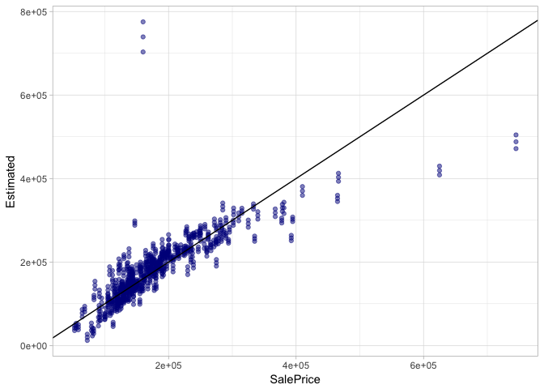

```r
test_plot = cbind(test_clean, Estimated = predict(train_model, test_clean, interval = "confidence") %>% as.vector())

ggplot(data = test_plot, aes(x = SalePrice, y = Estimated)) +
  geom_point(alpha = 0.5, color = "dark blue") + geom_abline(slope = 1) + theme_light()
```

```r
test_plot %>%
  mutate(sq = (SalePrice -Estimated)^2) %>%
  dplyr::select(sq) %>% as.vector() -> errs
OLS = sum(errs)

OLS
```

```
## [1] 2.200957e+12
```

۹. آیا قیمت ربط غیر خطی با یکی از ده متغیر استفاده شده دارد؟ بر اساس دستاوردهای خود مدل را بهتر نمایید.

با توجه به نموداری همانند نمودار قسمت ۲ که در پیوست نیز آمده است، می توان متغیرهایی که به نظر خطی نمی آیند را مجدداً بررسی و سپس طبق شکل ظاهری آن ها در نمودار تصحیح کرد. در این جا یک متغیر پیدا شده است ولی بقیه ی متغیرها را نمی توان به صورت مشخص گفت که با قیمت خطی نیستند.

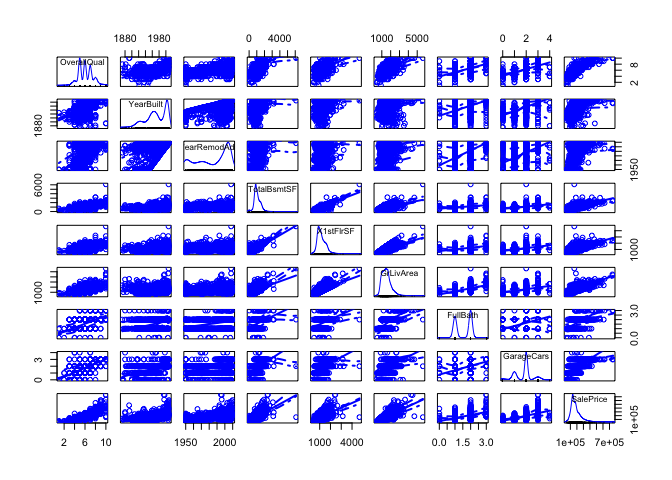

```r
scatterplotMatrix(x = houses_clean, formula = SalePrice ~ .)
```

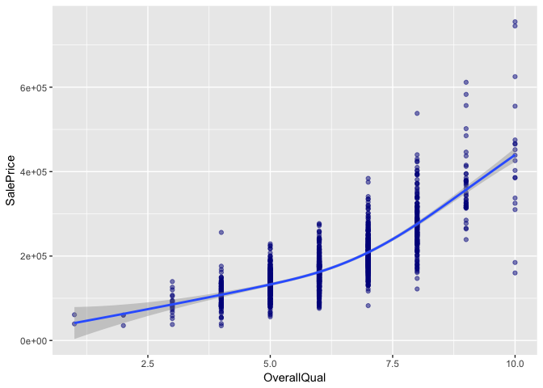

```r
ggplot(houses_clean, aes(x = OverallQual, y = SalePrice)) +
  geom_point(alpha = 0.5, color = "dark blue") +
  geom_smooth()
```

```r
fit = lm(formula = SalePrice ~ YearBuilt + YearRemodAdd + TotalBsmtSF + `1stFlrSF` + GrLivArea + FullBath + GarageCars +
                                        poly(OverallQual, 3), data = houses_clean)
summary(fit)
```

```
##
## Call:
## lm(formula = SalePrice ~ YearBuilt + YearRemodAdd + TotalBsmtSF +
##     `1stFlrSF` + GrLivArea + FullBath + GarageCars + poly(OverallQual,
##     3), data = houses_clean)
##
## Residuals:
##     Min      1Q  Median      3Q     Max
## -516896  -15817    -947   14288  232534
##
## Coefficients:
##                         Estimate Std. Error t value Pr(>|t|)
## (Intercept)           -1.135e+06  1.233e+05  -9.209  < 2e-16 ***
## YearBuilt              3.011e+02  4.709e+01   6.395 2.16e-10 ***
## YearRemodAdd           3.043e+02  5.941e+01   5.122 3.42e-07 ***
## TotalBsmtSF            1.702e+01  4.003e+00   4.253 2.25e-05 ***
## `1stFlrSF`             8.157e+00  4.613e+00   1.768   0.0772 .
## GrLivArea              4.887e+01  2.898e+00  16.863  < 2e-16 ***
## FullBath              -4.492e+03  2.481e+03  -1.810   0.0704 .
## GarageCars             1.347e+04  1.697e+03   7.939 4.06e-15 ***
## poly(OverallQual, 3)1  1.098e+06  5.885e+04  18.655  < 2e-16 ***
## poly(OverallQual, 3)2  5.202e+05  3.647e+04  14.266  < 2e-16 ***
## poly(OverallQual, 3)3  1.521e+05  3.659e+04   4.156 3.43e-05 ***
## ---
## Signif. codes:  0 '***' 0.001 '**' 0.01 '*' 0.05 '.' 0.1 ' ' 1
##
## Residual standard error: 35400 on 1449 degrees of freedom
## Multiple R-squared:  0.8028, Adjusted R-squared:  0.8014
## F-statistic: 589.8 on 10 and 1449 DF,  p-value: < 2.2e-16
```

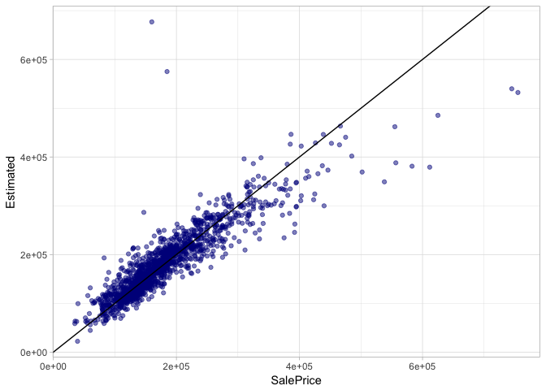

```r
houses_plot = cbind(houses_clean, Estimated = fitted(fit) %>% as.vector())
ggplot(data = houses_plot, aes(x = SalePrice, y = Estimated)) +
  geom_point(alpha = 0.5, color = "dark blue") + geom_abline(slope = 1) + theme_light()
```

۱۰. بر اساس مدل نهایی به دست آمده نتایج پیش بینی خود را بر روی test.csv به دست آورید و در سایت kaggle در مسابقه House Prices: Advanced Regression Techniques بارگذاری نمایید. سپس لینک رتبه و عدد آن را ضمیمه تمرین کنید.

rank = 3078 score = 0.17171